# Tutorial de GitHub

Máster Bioinformática UAM · IMDEA Nutrición

Este tutorial servirá para crear nuestro primer repositorio. Está dividido en dos partes:

1. Crear un repositorio **desde la web de GitHub**
2. Crear uno **desde el terminal** y subirlo con `push`.

Los bloques de código se pueden copiar directamente.

**Antes de empezar.** Necesitas: una cuenta en github.com, Git instalado en tu ordenador (comprueba con `git --version`) y, para el método del terminal, un **token personal (PAT)** o una **clave SSH**. GitHub ya no acepta la contraseña de la cuenta para subir código. Por eso para la clase de hoy sugerimos optar por crear el repositorio desde la web.

# 1 Crear un repositorio desde la web de GitHub

Esta es la vía más cómoda la primera vez: se crea todo desde el navegador y después, se puede descargar a tu ordenador.

## 1.1 Paso 1. Entrar y pulsar “New”

Inicia sesión en GitHub. Arriba a la derecha, en el símbolo **+**, elige **New repository** (o el botón verde **New** desde tu lista de repositorios).

[figure not shown]

## 1.2 Paso 2. Rellenar los datos del repositorio

- **Repository name**: sin espacios ni acentos (por ejemplo `practica_github`).
- **Description**: una línea explicando qué es. Opcional pero recomendable.
- **Public / Private**: público lo ve todo el mundo; privado solo tú y quien invites.
- **Add a README file**: márcalo. Es el archivo MD que se ve al abrir el repositorio.
- **Choose a license**:Es común añadir una. MIT por ejemplo si quieres permitir el uso libre citando la autoría.

[figure not shown]

## 1.3 Paso 3. Crear el repositorio

Pulsa **Create repository**. Ya tienes tu repositorio con su primer *commit* (el del README) hecho automáticamente.

[figure not shown]

## 1.4 Paso 4. Añadir y editar archivos desde el navegador

Con **Add file → Upload files** puedes arrastrar archivos desde tu ordenador. Con **Add file → Create new file** escribes uno directamente.

[figure not shown]

Para editar uno que ya existe, ábrelo y pulsa el **icono del lápiz**.

[figure not shown]

## 1.5 Paso 5. Hacer el commit

Al guardar cualquier cambio GitHub te pide un mensaje de *commit*.

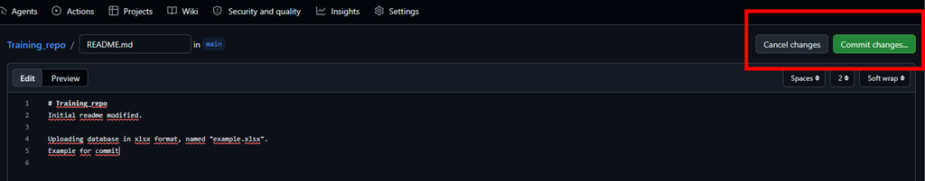

Escribe algo descriptivo (“Añado datos de campo 2025”, no “cambios”) y confirma con **Commit changes**.

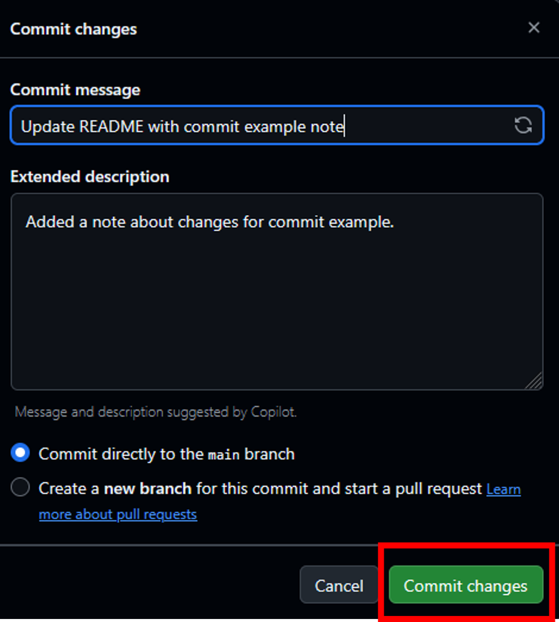

# 2 Crear un repositorio desde el terminal y hacer push

Aquí el repositorio se crea en tu ordenador y luego lo conectas con GitHub.

## 2.1 Configuración inicial (solo la primera vez)

Esto identifica tus commits únicamente. Se hace una vez por ordenador.

```bash
git config --global user.name "Tu Nombre"
git config --global user.email "tu.email@estudiante.uam.es"

# Rama por defecto llamada main (como en GitHub)
git config --global init.defaultBranch main

# Comprobar que ha quedado bien
git config --global --list
```

## 2.2 Crear la carpeta del proyecto e iniciar Git

```bash
# Ir a donde quieras crear el proyecto
cd ~/Documentos

# Crear la carpeta y entrar en ella
mkdir practica-github
cd practica-github

# Convertirla en un repositorio de Git
git init
```

## 2.3 Crear algún contenido

```bash
# Un README mínimo
echo "# Práctica GitHub" > README.md
echo "Repositorio de prueba para la clase del Máster." >> README.md
```

## 2.4 Crear el commit

```bash
# ¿Si quieres ver qué ha cambiado?
git status

# Preparar los archivos para el commit
git add README.md
# (o todos de golpe)
git add .

# Guardar el commit con su mensaje
git commit -m "Primer commit: README"

# Ver el historial
git log --oneline --graph --decorate
```

**add** y **commit** son dos pasos distintos a propósito: `add` elige *qué* cambios entran, `commit` lo registra. Puedes cambiar diez archivos y confirmar solo tres.

## 2.5 Crear el repositorio vacío en GitHub

Ve a GitHub y crea un repositorio **sin README, sin .gitignore y sin licencia** (*importante*: si lo creas con archivos, al hacer `push` chocará con el tuyo). Copia la URL que te da.

## 2.6 Conectar el repositorio local con GitHub

```bash
# Nombrar el remoto (origin) con la URL de tu repositorio
git remote add origin https://github.com/TU-USUARIO/practica-github.git

# Comprobar que ha quedado registrado
git remote -v

# Asegurar que la rama se llama main
git branch -M main
```

## 2.7 Subirlo: el primer push

```bash
# -u deja enlazada la rama local con la remota:
# a partir de ahora basta con "git push"
git push -u origin main
```

**Si te pide usuario y contraseña:** la contraseña de GitHub ya no vale. Crea un token en *Settings → Developer settings → Personal access tokens → Tokens (classic)*, marca la opción de permisos `repo` en el despegable, y pégalo donde pide la contraseña. Guárdalo: no se vuelve a mostrar.

⚠️ Recomendable ponerle un caducidad muy baja para este ejemplo (7 días) o eliminarlo al terminar la clase.

## 2.8 Clonar un repositorio que ya existe

```bash
# Descargar una copia completa, con todo su historial
git clone https://github.com/TU-USUARIO/practica-github.git

cd practica-github
```

## 2.9 Ramas: trabajar sin romper lo que funciona

```bash
# Crear una rama nueva y cambiarse a ella
git switch -c prueba-analisis

# ...haces cambios, add y commit como siempre...

# Volver a main
git switch main

# Incorporar el trabajo de la rama a main
git merge prueba-analisis

# Borrar la rama cuando ya no hace falta
git branch -d prueba-analisis
```

# 3 Chuleta rápida

| Comando | Para qué sirve |
| --- | --- |
| `git status` | Ver qué ha cambiado |
| `git add .` | Preparar todos los cambios |
| `git commit -m "..."` | Guardar los cambios preparados |
| `git push` | Subirlos a GitHub |
| `git pull` | Bajar los cambios de GitHub |
| `git log --oneline` | Ver el historial resumido |
| `git diff` | Ver las diferencias línea a línea |
| `git restore <archivo>` | Deshacer cambios sin confirmar |
| `git clone <url>` | Descargar un repositorio entero |

# 4 Si algo sale mal

```bash
# He hecho add de algo que no quería (sin commit todavía)
git restore --staged archivo.txt

# Quiero deshacer el último commit pero conservar los cambios
git reset --soft HEAD~1
```